# Osmoregulació en poliquets del gènere *Nereis*

J. Ignacio Lucas Lledó

4/4/2022

## Resultats

En la gràfica següent veiem els canvis de volum patits per cucs individuals en diferents medis al llarg del temps que va durar l’experiment. La línia vertical indica els 28 minuts després de la introducció del cuc el el medi experimental, i que correspon amb el moment en què els cucs van tornar a l’aigua marina.

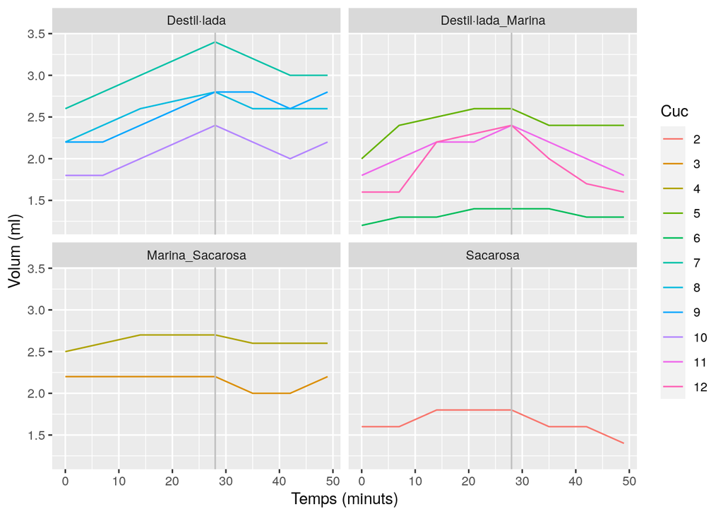

```r
library(tidyr)
library(plyr)
library(ggplot2)
cucs <- read.table('Cucs2.csv', header = TRUE, dec = ",",
                   colClasses = c('factor','factor','factor','numeric','numeric','numeric',
                                  'numeric','numeric','numeric','numeric','numeric'))
cucs$Cuc <- factor(cucs$Cuc, levels = as.character(2:12))
cucs$Subgrup <- factor(cucs$Subgrup, levels = c('L1','L2','L3','L4', 'A'))
cucs_l <- pivot_longer(cucs,
                       4:11,
                       names_to = 'Temps',
                       values_to = 'Volum',
                       names_prefix = "V_")
cucs_l$Temps <- as.numeric(cucs_l$Temps)
ggplot(data = cucs_l, mapping = aes(x = Temps, y = Volum, color = Cuc)) +
  geom_line() + facet_wrap(~Medi) + geom_vline(xintercept = 28, color = 'gray') +
  xlab('Temps (minuts)') + ylab('Volum (ml)')
```

Cada cuc té una mida inicial diferent. Per tal d’apreciar millor l’efecte de cada medi sobre la mida dels cucs, podem fer la mitjana del volum de tots els cucs que han estat en el mateix medi experimental, en cada moment. A continuació represente l’evolució mitjana de les mides dels cucs en cada medi i en cada subgrup:

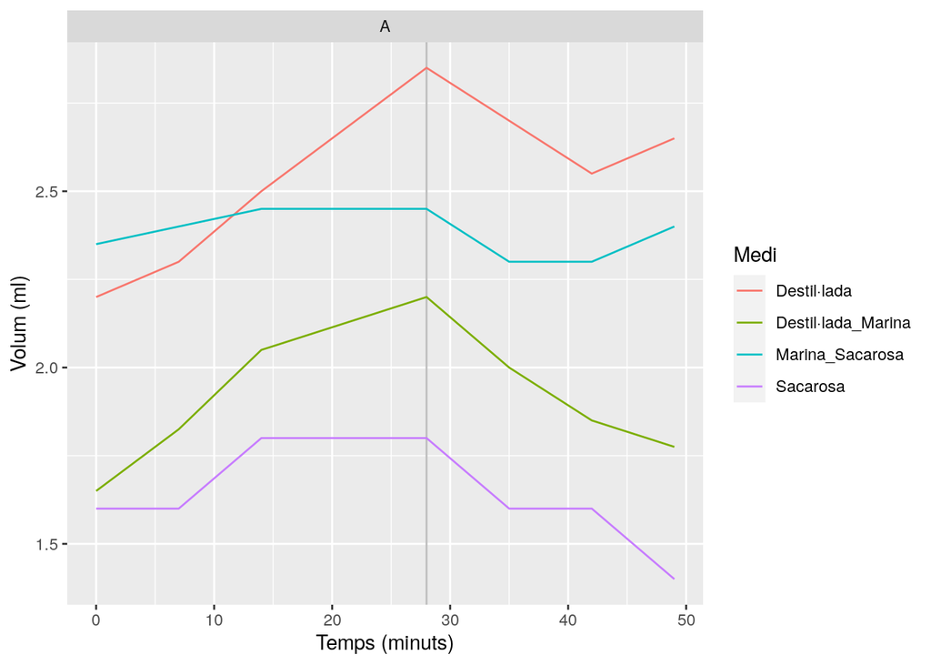

```r
cucs_m <- ddply(cucs_l, c('Subgrup','Medi', 'Temps'),
                function(x) mean(x$Volum))
names(cucs_m)[4] <- 'Volum'
ggplot(data = cucs_m, mapping = aes(x = Temps, y = Volum, color = Medi)) +
  geom_vline(xintercept = 28, color = 'gray') +
  geom_line() +
  facet_wrap(~Subgrup) + xlab('Temps (minuts)') + ylab('Volum (ml)')
```

Bona part de les diferències que observem entre les línies de la gràfica anterior es deuen a què els cucs tenen mides molt variables. Allò que realment ens interessa no és que uns cucs siguen més grans que altres, sinó com canvia la seua mida al llarg del temps. Si expressem el canvi de mida en unitats **relatives** a la mida inicial, els diferents cucs seran més comparables.

A continuació transforme la mida de cada cuc *i* en cada moment *t* ($V_{it}$) en la proporció la proporció que representa el canvi respecte de la mida inicial, $\frac{V_{it} - V_{i0}}{V_{i0}}$. Així posem les dades de tots els cucs en la mateixa escala i podem observar millor la tendència dels canvis en cada medi:

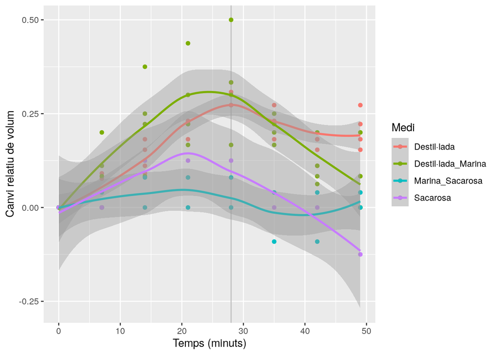

```r
cucs_p <- ddply(cucs_l,
                c('Subgrup','Medi','Cuc'),
                function(x) {
                  Inici = x[x$Temps == 0,'Volum']
                  data.frame(Temps = x$Temps,
                             Volum = (x$Volum - Inici) / Inici
                  )})
ggplot(data = cucs_p, mapping = aes(x = Temps, y = Volum, color = Medi)) +
  geom_vline(xintercept = 28, color = 'gray') + geom_point() + geom_smooth()  +
  xlab('Temps (minuts)') + ylab('Canvi relatiu de volum')
```